# Advanced Empirical Finance: Topics and Data Science

Shrinking the SDF

Stefan Voigt

University of Copenhagen and Danish Finance Institute (DFI)

Spring 2027

## Today

- Cross-validation: choosing the penalty
- The SDF of the zoo and a prior on Sharpe ratios
- Sparse in anomalies or in principal components?

## Which penalty?

- **Lecture 10:** 158 anomalies, estimation sample 1973–1999, test sample 2000–2023. The plug-in portfolio falls from 15.72 to 2.51
- Ridge and the lasso do better in the test sample for a wide range of $\lambda$: with ridge, between 1.47 and 2.92
- The best $\lambda$ in the test sample is no option: an investor in 1999 does not know the test sample

**Today:** choose $\lambda$ with the estimation sample only, and give the penalty an economic meaning

# Cross-validation

## Cross-validation for time series

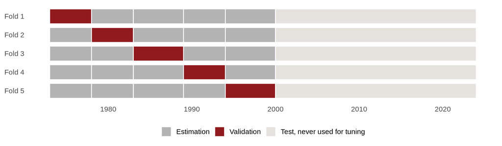

- Each penalty is judged on data it was not estimated on: 5 consecutive blocks of the estimation sample, each one the validation block once
- Months are not shuffled into the folds: neighbouring months share news and volatility, so shuffling would leak information into the validation block
- The test sample stays untouched until the very end

## Cross-validation in code

- R
- Python

```r
# Five consecutive blocks: estimate on four, Sharpe ratio on the fifth
folds <- ceiling(seq_len(nrow(x_estimation)) / (nrow(x_estimation) / n_folds))

cv_sharpe <- function(fit_weights, lambda) {
  map_dbl(seq_len(n_folds), \(k) {
    weights <- fit_weights(x_estimation[folds != k, ], lambda)
    sharpe_ratio(x_estimation[folds == k, ] %*% weights)
  }) |>
    mean(na.rm = TRUE)
}

ridge_cv <- map_dbl(ridge_lambdas, \(lambda) cv_sharpe(ridge_weights, lambda))
ridge_lambda <- ridge_lambdas[which.max(ridge_cv)]
lasso_cv <- map_dbl(lasso_lambdas, \(lambda) cv_sharpe(lasso_weights, lambda))
lasso_lambda <- lasso_lambdas[which.max(lasso_cv)]
```

```python
# Five consecutive blocks: estimate on four, Sharpe ratio on the fifth
folds = np.ceil(np.arange(1, len(x_estimation) + 1) / (len(x_estimation) / n_folds))


def cv_sharpe(fit_weights, lam):
    sharpes = [sharpe_ratio(x_estimation[folds == k] @ fit_weights(x_estimation[folds != k], lam))
               for k in range(1, n_folds + 1)]
    return np.nanmean(sharpes)


ridge_cv = [cv_sharpe(ridge_weights, lam) for lam in ridge_lambdas]
ridge_lambda = ridge_lambdas[np.argmax(ridge_cv)]
lasso_cv = [cv_sharpe(lasso_weights, lam) for lam in lasso_lambdas]
lasso_lambda = lasso_lambdas[np.argmax(lasso_cv)]
```

`x_estimation`, `sharpe_ratio()`, `ridge_weights()` and `lasso_weights()` as in lecture 10. Chosen: $\lambda$ = 10⁻⁴ for ridge (test Sharpe ratio 2.89), 3.2 × 10⁻⁴ for the lasso (74 anomalies, 2.96)

# The SDF of the zoo

## Whiteboard: the SDF of the zoo

Find the SDF $m = 1 - b'(F - E[F])$ that prices all anomaly returns $F$: $E[m\,F] = 0$

$$E[m\,F] = \mu - E\big[F(F - \mu)'\big]\,b = \mu - \Sigma b = 0 \qquad \Longrightarrow \qquad b = \Sigma^{-1}\mu$$

- The SDF’s loadings are the weights of the mean-variance efficient portfolio (lecture 6): estimating the SDF and choosing the best portfolio of the zoo are the same problem
- Each anomaly is a characteristic-managed portfolio, a long-short sort (lectures 7 and 8). $b$ says how much each characteristic matters for prices

## Whiteboard: a prior on Sharpe ratios

Kozak, Nagel & Santosh (2020): before seeing the data, $\mu \sim N\big(0, \tfrac{\kappa^2}{\tau}\Sigma^2\big)$ with $\tau = \text{tr}(\Sigma)$. What does this prior say about the squared maximum Sharpe ratio $\mu'\Sigma^{-1}\mu$?

$$E\big[\mu'\Sigma^{-1}\mu\big] = \kappa^2 \qquad \hat b = (\Sigma + \lambda I)^{-1}\hat\mu \quad \text{with} \quad \lambda = \frac{\tau}{\kappa^2 T}$$

- The posterior mean of $b$ is a ridge estimator: the penalty of lecture 10 is a prior about how large Sharpe ratios can be
- Prior means are small for principal components with little variance: a large Sharpe ratio from a low-variance combination of anomalies is implausible

## The prior behind cross-validation

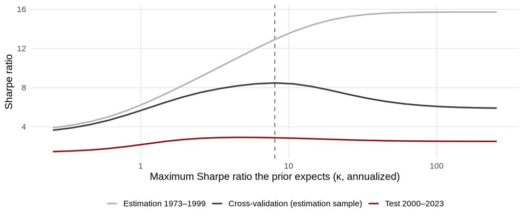

- The cross-validated $\lambda$ = 10⁻⁴ means a prior that expects a maximum Sharpe ratio of about **8.1** a year: still optimistic, but far below the plug-in’s 15.7
- Same portfolio as ridge on the regression of lecture 10 (correlation of the weights 1.00): the prior is the reason for the penalty, not a new method

## How many anomalies does the SDF need?

How many of the 158 anomalies does a good SDF of the zoo need?

- Fewer than 5
- 5 to 20
- 20 to 50
- More than 50

# Sparse in anomalies or in principal components?

## Principal components as portfolios

- Kozak, Nagel & Santosh: an SDF with a few anomalies prices badly; an SDF with a few **principal components** of the anomalies prices well
- A principal component is a portfolio of all anomalies: rotate the returns, run the lasso on the components, rotate the weights back
- R
- Python

```r
pc_lasso_weights <- function(x, lambda) {
  components <- eigen(cov(x), symmetric = TRUE)$vectors
  components %*% lasso_weights(x %*% components, lambda)
}

pc_lasso_cv <- map_dbl(lasso_lambdas, \(lambda) cv_sharpe(pc_lasso_weights, lambda))
pc_lasso_lambda <- lasso_lambdas[which.max(pc_lasso_cv)]
```

```python
def pc_lasso_weights(x, lam):
    _, components = np.linalg.eigh(np.cov(x, rowvar=False))
    return components @ lasso_weights(x @ components, lam)


pc_lasso_cv = [cv_sharpe(pc_lasso_weights, lam) for lam in lasso_lambdas]
pc_lasso_lambda = lasso_lambdas[np.argmax(pc_lasso_cv)]
```

The principal components come from the estimation folds only, also inside the cross-validation

## Sparse in what?

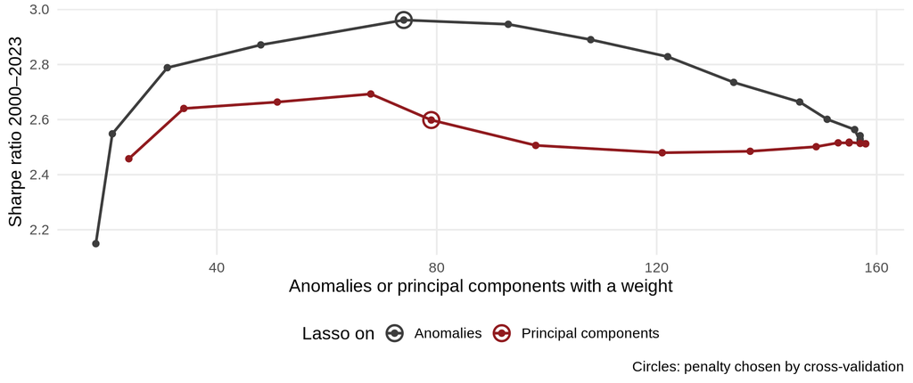

- On our zoo, the components are **not** sparser: 79 components give 2.60 in the test sample, 74 anomalies give 2.96
- Neither is sparse: a good SDF of the zoo needs dozens of anomalies or components, not a handful

## Beyond one SDF: averaging over models

- Every penalty, every sparse set of anomalies is one model of the SDF. Which one is right is uncertain, too
- **Bayesian model averaging** (Bryzgalova, Huang & Julliard, 2023): weight every combination of factors by its posterior probability and average the SDFs
- Their finding: no small set of factors dominates; the averaged SDF is dense, in line with the scoreboard

## Scoreboard

| Portfolio | Inputs | Sharpe ratio 1973–1999 | Sharpe ratio 2000–2023 |
| --- | --- | --- | --- |
| Market | Market | 0.47 | 0.42 |
| 1/N over all anomalies | 158 anomalies | 2.79 | 1.43 |
| Plug-in mean-variance | 158 anomalies | 15.72 | 2.51 |
| Ridge (prior on Sharpe ratios) | 158 anomalies | 12.92 | 2.89 |
| Lasso on anomalies | 74 anomalies | 11.46 | 2.96 |
| Lasso on principal components | 79 components | 12.15 | 2.60 |

- Every penalty chosen by cross-validation in the estimation sample
- **Lecture 12:** a few factors from the principal components, chosen for their premium instead of their variance